# Pokamon

Team White

# Pokémon Dataset Analysis

## Overview

### Dataset Description

- **Name**: The English name of the Pokémon
- **Japanese Name**: The Original Japanese name of the Pokémon
- **Pokedex Number**: The entry number of the Pokémon in the National Pokedex
- **Percentage Male**: The percentage of the male species (blank if genderless)
- **Type 1**: The Primary Type of the Pokémon
- **Type 2**: The Secondary Type of the Pokémon
- **Classification**: The Pokémon’s classification as described by the Sun and Moon Pokedex
- **Height (m)**: Height of the Pokémon in meters
- **Weight (kg)**: The Weight of the Pokémon in kilograms
- **Capture Rate**: Capture Rate of the Pokémon
- **Base Egg Steps**: The number of steps required to hatch an egg of the Pokémon
- **Abilities**: A stringified list of abilities that the Pokémon is capable of having
- **Experience Growth**: The Experience Growth of the Pokémon
- **Base Happiness**: Base Happiness of the Pokémon
- **Against_?**: Eighteen features that denote the amount of damage taken against an attack of a particular type
- **HP**: The Base HP of the Pokémon
- **Attack**: The Base Attack of the Pokémon
- **Defense**: The Base Defense of the Pokémon
- **Special Attack**: The Base Special Attack of the Pokémon
- **Special Defense**: The Base Special Defense of the Pokémon
- **Speed**: The Base Speed of the Pokémon
- **Generation**: The numbered generation in which the Pokémon was first introduced
- **Is Legendary**: Denotes if the Pokémon is legendary

```r
library(tidyverse)
library(randomForest)
library(viridis)
library(rgl)
library(reshape2)
```

# Load necessary libraries

library(ggplot2)

```r
# Assign variable to my data
url <- "repo-structure/data/pokemon.csv"
url2 <- "repo-structure/data/pokemon2.csv"
pokemon_data <- read.csv(url)
pokemon_data2 <- read.csv(url2)
merged_pokemon_data <-merge(pokemon_data, pokemon_data2, by.x="Name", by.y="name")

glimpse(merged_pokemon_data)
```

```
## Rows: 704
## Columns: 53
## $ Name              <chr> "Abomasnow", "Abra", "Absol", "Accelgor", "Aerodacty…
## $ X.                <int> 460, 63, 359, 617, 142, 306, 190, 65, 594, 334, 698,…
## $ Type_1            <chr> "Grass", "Psychic", "Dark", "Bug", "Rock", "Steel", …
## $ Type_2            <chr> "Ice", "", "", "", "Flying", "Rock", "", "", "", "Fl…
## $ Total             <int> 494, 310, 465, 495, 515, 530, 360, 500, 470, 490, 36…
## $ HP                <int> 90, 25, 65, 80, 80, 70, 55, 55, 165, 75, 77, 75, 114…
## $ Attack            <int> 92, 20, 130, 70, 105, 110, 70, 50, 75, 70, 59, 100, …
## $ Defense           <int> 75, 15, 60, 40, 65, 180, 55, 45, 80, 90, 50, 66, 70,…
## $ Sp_Atk            <int> 92, 105, 75, 100, 60, 60, 40, 135, 40, 70, 67, 60, 8…
## $ Sp_Def            <int> 85, 55, 60, 60, 75, 60, 55, 95, 45, 105, 63, 66, 80,…
## $ Speed             <int> 60, 90, 75, 145, 130, 50, 85, 120, 65, 80, 46, 115, …
## $ Generation        <int> 4, 1, 3, 5, 1, 3, 2, 1, 5, 3, 6, 4, 5, 2, 3, 1, 1, 4…
## $ Legendary         <chr> "False", "False", "False", "False", "False", "False"…
```

[output cut: 40 more lines]

```r
# Sample data (replace with your actual dataset)
merged_pokemon_data_frame <- data.frame(
  name = c("Pikachu", "Charizard", "Bulbasaur", "Squirtle", "Jigglypuff"),
  height_m = c(0.4, 1.7, 0.7, 0.5, 0.5),
  weight_kg = c(6, 90.5, 6.9, 9, 5.5)
)
```

# Scatter plot: Height vs. Weight

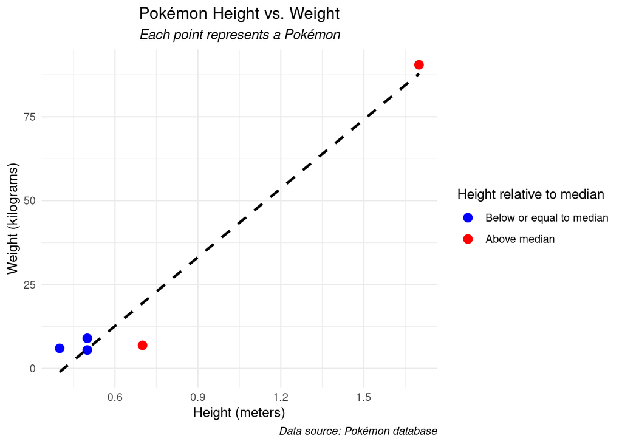

```r
ggplot(merged_pokemon_data_frame, aes(x = height_m, y = weight_kg)) +
  geom_point(aes(color = as.factor(height_m > median(height_m))), size = 3) +
  scale_color_manual(values = c("blue", "red"),
                     name = "Height relative to median",
                     labels = c("Below or equal to median", "Above median")) +
  geom_smooth(method = "lm", se = FALSE, color = "black", linetype = "dashed") +
  labs(title = "Pokémon Height vs. Weight",
       subtitle = "Each point represents a Pokémon",
       caption = "Data source: Pokémon database",
       x = "Height (meters)",
       y = "Weight (kilograms)") +
  theme_minimal() +
  theme(plot.title = element_text(hjust = 0.5),
        plot.subtitle = element_text(hjust = 0.5, face = "italic"),
        plot.caption = element_text(hjust = 1, face = "italic"))
```

## Bar Plot: Pokémon Types Frequency

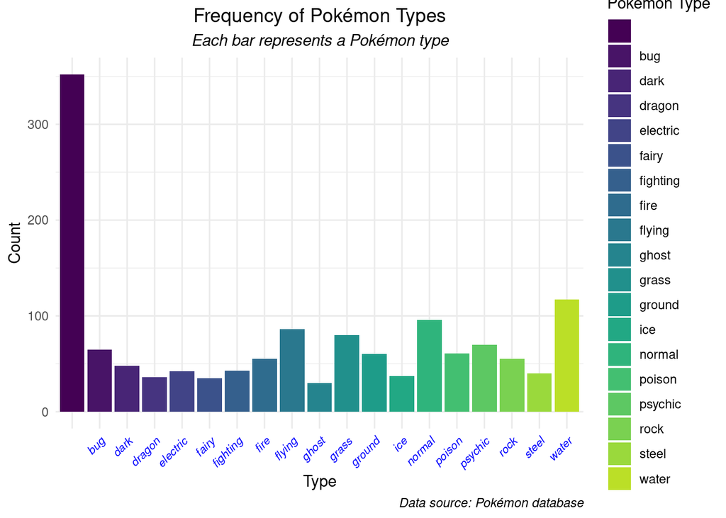

```r
# Reshape the data
reshaped_data <- merged_pokemon_data %>%
  gather(key = "type_key", value = "type_value", "type1", "type2") %>%
  filter(!is.na(type_value))


# install the viridis package
# install.packages("viridis")

# Load the viridis package
library(viridis)

# Plot
ggplot(reshaped_data, aes(x = type_value, fill = type_value)) +
  geom_bar(show.legend = TRUE) +
  scale_fill_viridis_d(name = "Pokémon Type", option = "viridis", end = 0.9) +
  labs(title = "Frequency of Pokémon Types",
       subtitle = "Each bar represents a Pokémon type",
       caption = "Data source: Pokémon database",
       x = "Type",
       y = "Count") +
  theme_minimal() +
  theme(plot.title = element_text(hjust = 0.5),
        plot.subtitle = element_text(hjust = 0.5, face = "italic"),
        plot.caption = element_text(hjust = 1, face = "italic"),
        axis.text.x = element_text(face = "italic", color = "blue", size = 8, angle = 45, hjust = 1))
```

## Histogram: Pokémon HP Distribution

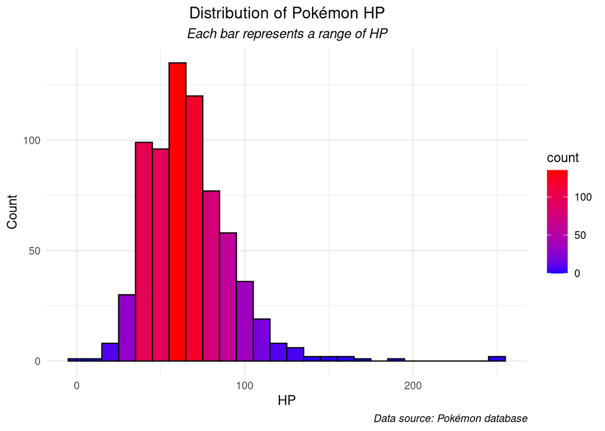

```r
# Plot
ggplot(merged_pokemon_data, aes(x = hp, fill = ..count..)) +
  geom_histogram(binwidth = 10, color = "black", show.legend = TRUE) +
  scale_fill_gradient(name = "count", low = "blue", high = "red") +
  labs(title = "Distribution of Pokémon HP",
       subtitle = "Each bar represents a range of HP",
       caption = "Data source: Pokémon database",
       x = "HP",
       y = "Count") +
  theme_minimal() +
  theme(plot.title = element_text(hjust = 0.5),
        plot.subtitle = element_text(hjust = 0.5, face = "italic"),
        plot.caption = element_text(hjust = 1, face = "italic"))
```

## Box Plot: Pokémon Attack by Type

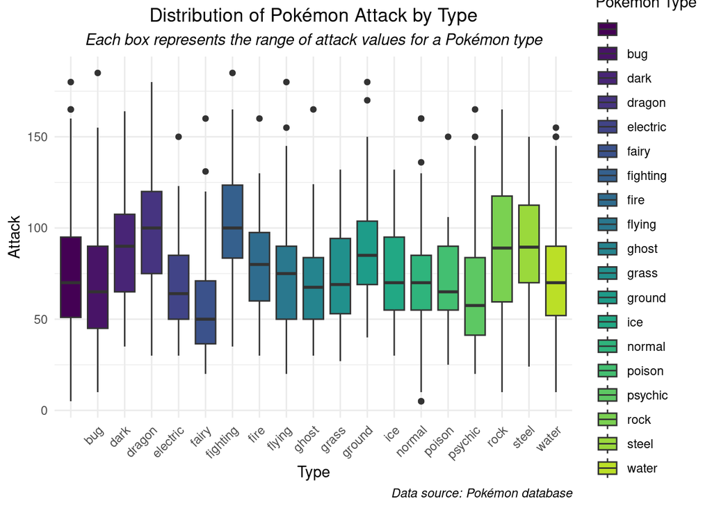

```r
# Reshape the data
reshaped_data <- merged_pokemon_data %>%
  gather(key = "type_key", value = "type_value", "type1", "type2") %>%
  filter(!is.na(type_value))

# Plot
ggplot(reshaped_data, aes(x = type_value, y = attack, fill = type_value)) +
  geom_boxplot(show.legend = TRUE) +
  scale_fill_viridis_d(name = "Pokémon Type", option = "viridis", end = 0.9) +
  labs(title = "Distribution of Pokémon Attack by Type",
       subtitle = "Each box represents the range of attack values for a Pokémon type",
       caption = "Data source: Pokémon database",
       x = "Type",
       y = "Attack") +
  theme_minimal() +
  theme(plot.title = element_text(hjust = 0.5),
        plot.subtitle = element_text(hjust = 0.5, face = "italic"),
        plot.caption = element_text(hjust = 1, face = "italic"),
        axis.text.x = element_text(angle = 45, hjust = 1))  # Rotate x-axis labels
```

#Scatter Plot: Pokémon Special Attack vs. Defense

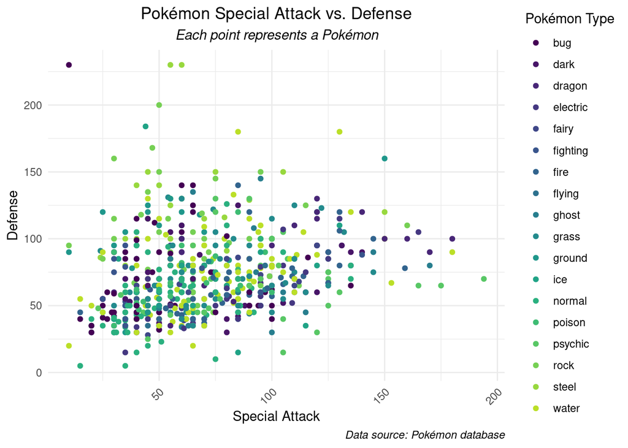

```r
#ggplot(merged_pokemon_data, aes(x = "sp_attack", y = "defense")) +
 # geom_point(color = "orange") +
  #labs(title = "Pokémon Special Attack vs. Defense",
   #    x = "Special Attack",
    #   y = "Defense") +
  #theme_minimal()

# Plot
ggplot(merged_pokemon_data, aes(x = sp_attack, y = defense, color = type1)) +
  geom_point() +
  scale_color_viridis_d(name = "Pokémon Type", option = "viridis", end = 0.9) +
  labs(title = "Pokémon Special Attack vs. Defense",
       subtitle = "Each point represents a Pokémon",
       caption = "Data source: Pokémon database",
       x = "Special Attack",
       y = "Defense") +
  theme_minimal() +
  theme(plot.title = element_text(hjust = 0.5),
        plot.subtitle = element_text(hjust = 0.5, face = "italic"),
        plot.caption = element_text(hjust = 1, face = "italic"),
        axis.text.x = element_text(angle = 45, hjust = 1))  # Rotate x-axis labels
```

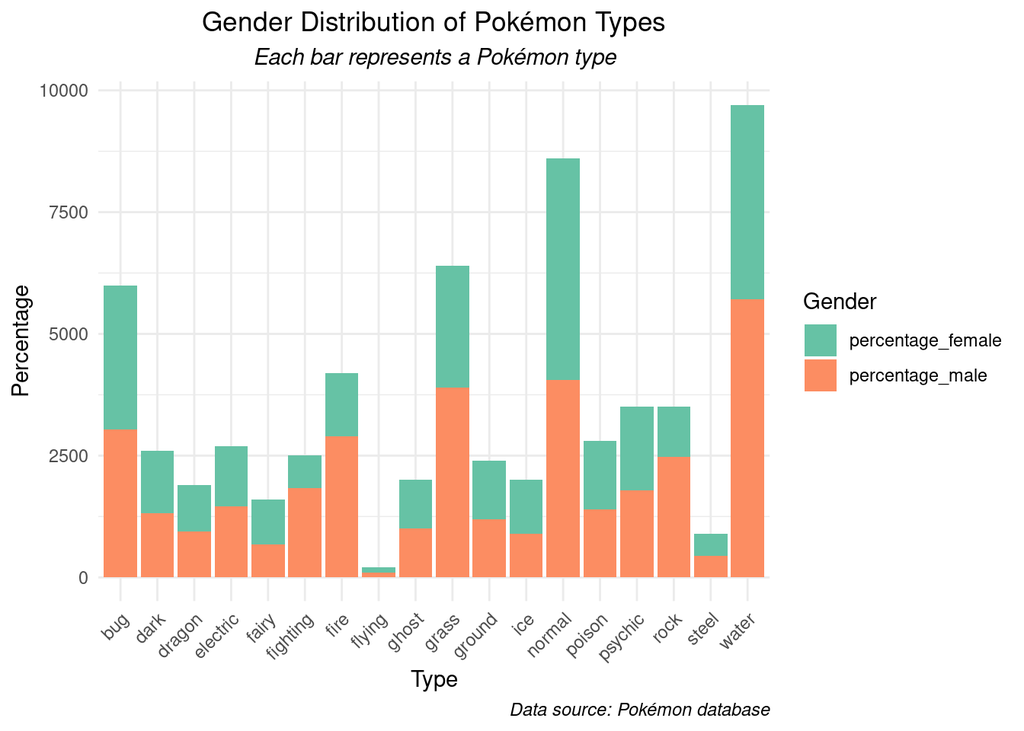

```r
# Calculate the percentage of females for each type
merged_pokemon_data$percentage_female <- 100 - merged_pokemon_data$percentage_male

# Reshape the data
reshaped_data <- merged_pokemon_data %>%
  gather(key = "gender", value = "percentage", percentage_male, percentage_female)

# Plot
ggplot(reshaped_data, aes(x = type1, y = percentage, fill = gender)) +
  geom_bar(stat = "identity", position = "stack") +
  scale_fill_brewer(palette = "Set2", name = "Gender") +
  labs(title = "Gender Distribution of Pokémon Types",
       subtitle = "Each bar represents a Pokémon type",
       caption = "Data source: Pokémon database",
       x = "Type",
       y = "Percentage") +
  theme_minimal() +
  theme(plot.title = element_text(hjust = 0.5),
        plot.subtitle = element_text(hjust = 0.5, face = "italic"),
        plot.caption = element_text(hjust = 1, face = "italic"),
        axis.text.x = element_text(angle = 45, hjust = 1))  # Rotate x-axis labels
```

## Line Plot: Pokémon Experience Growth Over Generations

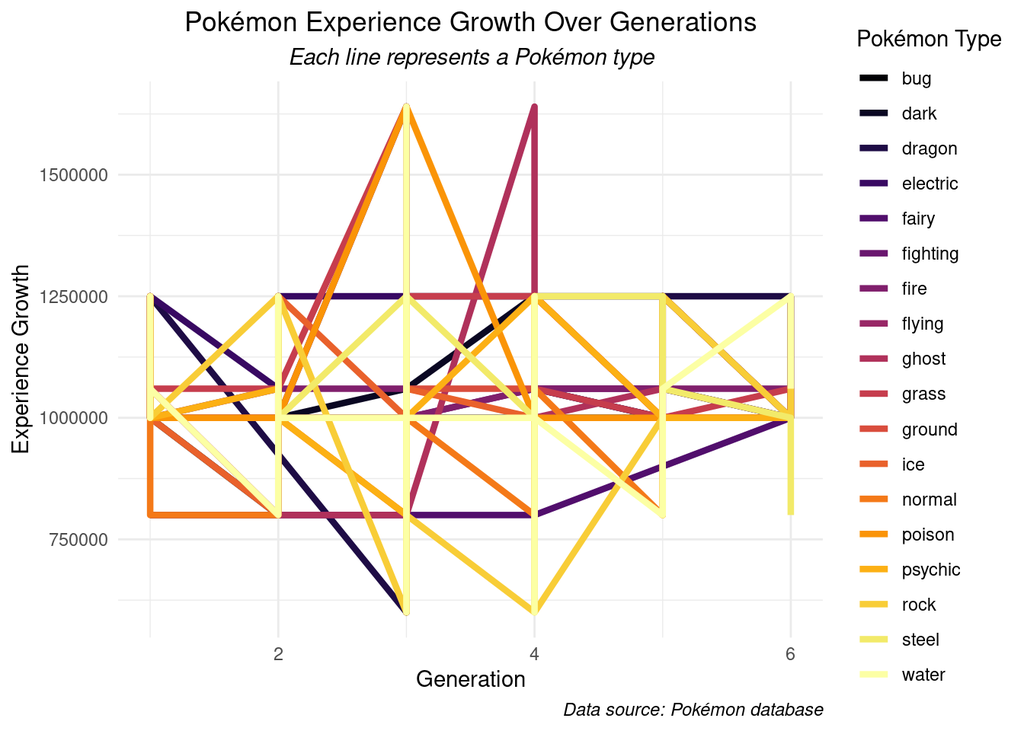

```r
# Plot
ggplot(merged_pokemon_data, aes(x = generation, y = experience_growth, color = type1, group = type1)) +
  geom_line(size = 1.5) +  # Increase the size value as needed
  scale_color_viridis_d(option = "inferno", name = "Pokémon Type") +
  labs(title = "Pokémon Experience Growth Over Generations",
       subtitle = "Each line represents a Pokémon type",
       caption = "Data source: Pokémon database",
       x = "Generation",
       y = "Experience Growth") +
  theme_minimal() +
  theme(plot.title = element_text(hjust = 0.5),
        plot.subtitle = element_text(hjust = 0.5, face = "italic"),
        plot.caption = element_text(hjust = 1, face = "italic"))
```

## Density Plot: Pokémon Speed Distribution

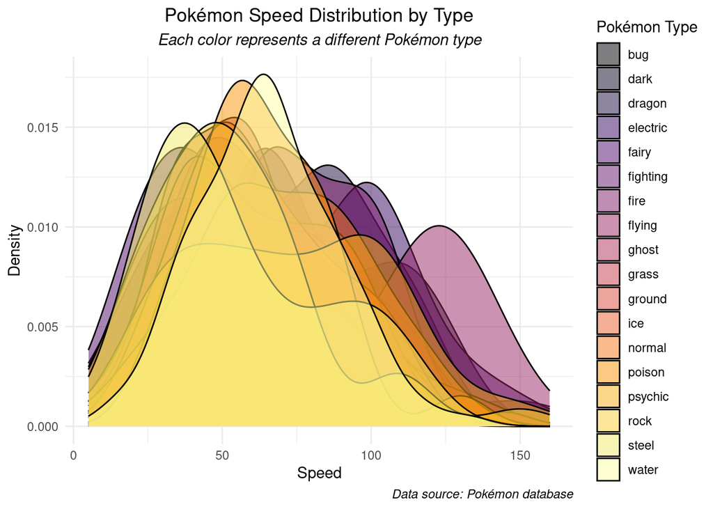

```r
# Create a density plot of Pokémon speed
ggplot(merged_pokemon_data, aes(x = speed, fill = type1)) +  # Map 'type1' to fill aesthetic
  geom_density(alpha = 0.5) +  # Set transparency to see overlapping areas
  scale_fill_viridis_d(option = "inferno", name = "Pokémon Type") +  # Use a vivid color palette and add a legend
  labs(title = "Pokémon Speed Distribution by Type",
       subtitle = "Each color represents a different Pokémon type",
       caption = "Data source: Pokémon database",
       x = "Speed",
       y = "Density") +
  theme_minimal() +
  theme(plot.title = element_text(hjust = 0.5),
        plot.subtitle = element_text(hjust = 0.5, face = "italic"),
        plot.caption = element_text(hjust = 1, face = "italic"))
```

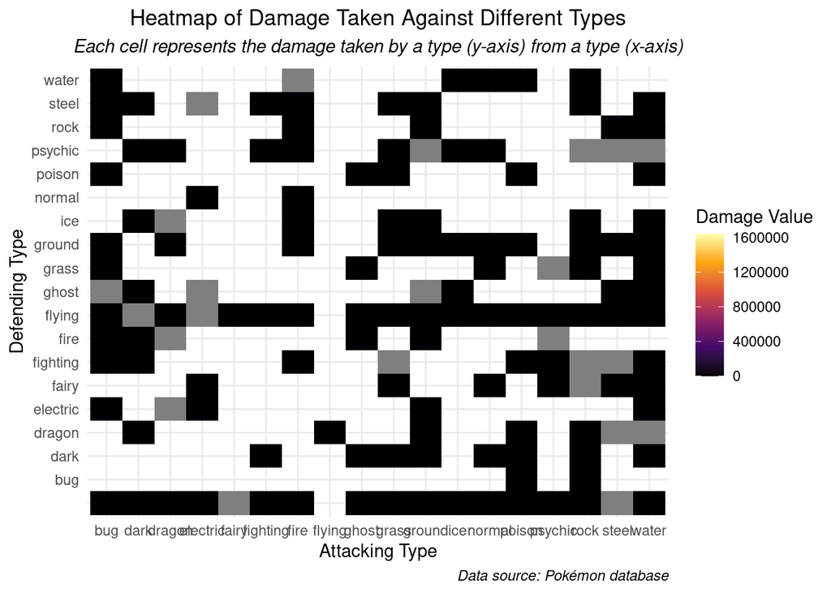

```r
# Assuming damage_matrix is your data frame
# Melt the data frame to a format suitable for ggplot
melted_merged_pokemon_data <- melt(merged_pokemon_data)
# Create a heatmap
ggplot(data = melted_merged_pokemon_data, aes(x = type1, y = type2, fill = value)) +
  geom_tile() +
  scale_fill_viridis_c(option = "inferno", name = "Damage Value") +  # Use a vivid color palette and add a legend
  labs(title = "Heatmap of Damage Taken Against Different Types",
       subtitle = "Each cell represents the damage taken by a type (y-axis) from a type (x-axis)",
       caption = "Data source: Pokémon database",
       x = "Attacking Type",
       y = "Defending Type") +
  theme_minimal() +
  theme(plot.title = element_text(hjust = 0.5),
        plot.subtitle = element_text(hjust = 0.5, face = "italic"),
        plot.caption = element_text(hjust = 1, face = "italic"))
```

## Bar Plot: Legendary vs. Non-Legendary Pokémon

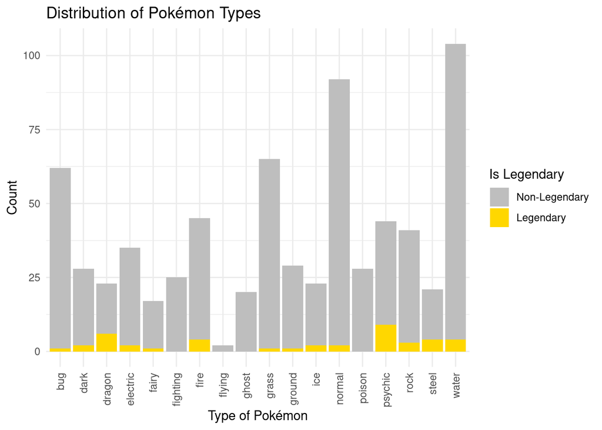

```r
# Assuming 'type' is the column in your data that represents the type of Pokémon
ggplot(merged_pokemon_data, aes(x = factor(type1), fill = factor(is_legendary))) +
  geom_bar() +
  labs(title = "Distribution of Pokémon Types",
       x = "Type of Pokémon",
       y = "Count",
       fill = "Is Legendary") +  # This adds a label to the legend
  scale_fill_manual(values = c("gray", "gold"),
                    labels = c("Non-Legendary", "Legendary")) +  # This specifies the labels for the legend
  theme_minimal() +
  theme(axis.text.x = element_text(angle = 90, vjust = 0.5, hjust=1))  # This rotates the x-axis labels
```

## Correlation Matrix Plot

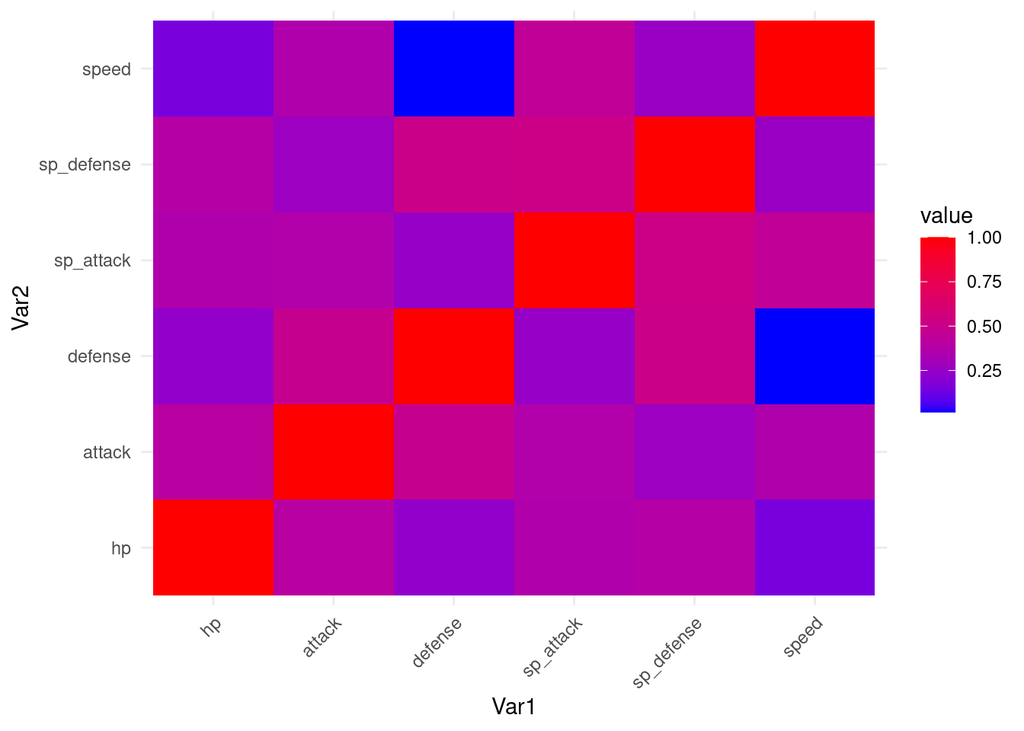

```r
# Calculate correlation matrix
cor_matrix <- cor(merged_pokemon_data[, c("hp", "attack", "defense", "sp_attack", "sp_defense", "speed")])

# Reshape the correlation matrix
cor_melt <- melt(cor_matrix)

# Create the plot
ggplot(data = cor_melt, aes(x = Var1, y = Var2, fill = value)) +
  geom_tile() +
  scale_fill_gradient(low = "blue", high = "red") +
  theme_minimal() +
  theme(axis.text.x = element_text(angle = 45, hjust = 1))
```

```r
#cor_matrix <- cor(merged_pokemon_data[, c("hp", "attack", "defense", "sp_attack", "sp_defense", "speed")])
#ggplot(data = cor_matrix, aes(x = rownames(cor_matrix), y = colnames(cor_matrix))) +
  #geom_tile(aes(fill = value)) +
  #scale_fill_gradient(low = "blue", high = "red") +
  #theme_minimal() +
  #theme(axis.text.x = element_text(angle = 45, hjust = 1))
```